# Sociología del Género

SOL3061 | Clase 1: Introducción

Tania Hutt

## Plan de clase

- Empezar a conocernos
- El curso y el programa
- Dudas, preguntas, sugerencias
- Recorrido a los estudios de sociología del género en el tiempo

## Un poco sobre mí

- Tania Hutt (ella/la). Socióloga, Ph.D.
- Desigualdad de género en el mercado laboral, discriminación en procesos de selección y evaluación.
- Trayectorias laborales durante la transición a la maternidad.
- Estereotipos y discriminación por maternidad y maternidad futura.
- Sobre mi posicionalidad en el curso
- Lo que este curso es y no es

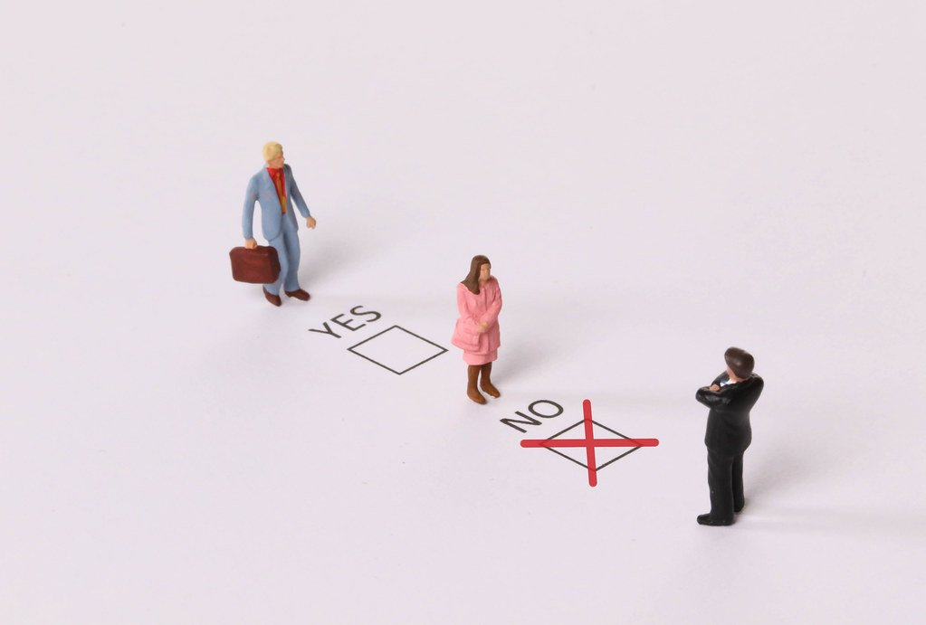

[This Photo](https://foto.wuestenigel.com/the-concept-of-gender-discrimination-in-recruitment/) by Unknown Author is licensed under [CC BY](https://creativecommons.org/licenses/by/3.0/)

## Por favor revisar el programa en detalle

- Políticas del curso con respecto a integridad académica y justificación de inasistencias.
- Detalle sobre las evaluaciones
- Calendarización completa (siempre sujeta a pequeños cambios): revisar fechas de entregas.
- Sobre las lecturas:
  - Mínimas marcadas con **
  - Las demás son opcionales pero recomendadas
  - Todo disponible en Canvas, bajo “Archivos”

## Anotación social de las lecturas (Hypothesis)

**✅ Qué se pide:**

- Al menos **2 anotaciones por texto obligatorio** (**), cada una anclada a un pasaje.
- Cada anotación lleva una etiqueta: `pregunta`, `crítica/tensión`, `conexión` o `respuesta` (a una compañera/o).
- Las anotaciones de un mismo texto no pueden ser todas del mismo tipo.

**Martes a las 23:59** antes de la clase. Mejor si anotan antes: quien lidera las usa para preparar la discusión.

**❌ Qué NO debe ser:**

- Un resumen del pasaje o un simple subrayado.
- Comentarios como “interesante” o “estoy de acuerdo”.
- Escrito por IA.

**💭 Una buena anotación:**

- Tiene 2–3 oraciones: qué observas y por qué.
- Agrega algo propio: una duda genuina, una tensión, una conexión con otra lectura o un caso que conoces.

## Buenas prácticas

- Preparación antes de la clase: lectura profunda y reflexiva de los materiales
- Profesionalismo y compromiso
  - Asistencia y puntualidad
  - Sobre inasistencias
- Participación en clases: escuchar de manera atenta y contribuir con tus ideas, preguntas y reflexiones.

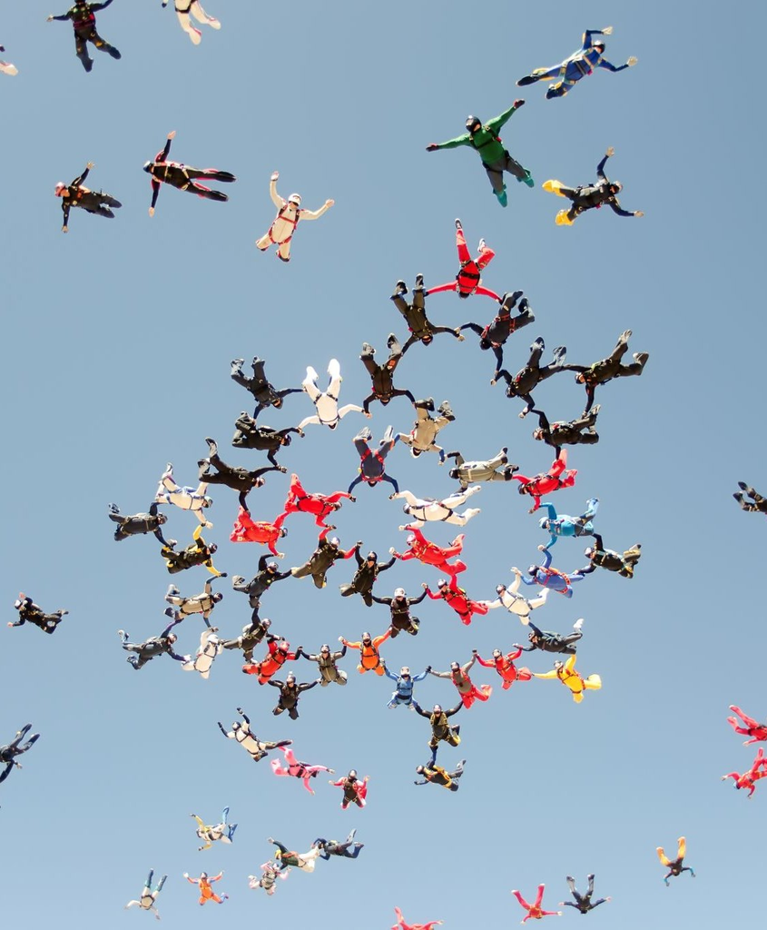

## Cómo leer un paper académico de manera estratégica

[figure not shown]

**Abstract/Resumen:** visión general del paper. **Leer siempre con mucha atención.**

[figure not shown]

**Introducción:** pregunta y relevancia del estudio. Escanear o leer las oraciones clave.

[figure not shown]

**Métodos:** ¿qué hicieron? Escanear o leer las oraciones clave.

[figure not shown]

**Resultados:** ¿qué encontraron? Revisa tablas, figuras, y oraciones clave.

[figure not shown]

**Discusión/Conclusión:** ¿qué significan los hallazgos y por qué importan? Leer los primeros párrafos y escanear lo demás.

## Cómo leer un paper académico de manera estratégica

- No necesitan leer todo con el mismo nivel de detalle.
- Preguntarse siempre:
  - ¿Cuál es la pregunta central?
  - ¿Cómo la responden?
  - ¿Qué aportan a la sociología del género?
  - ¿Cómo se conecta con mis intereses?

## Para abrir

Piensen en un curso o un texto que hayan leído en sociología.

- ¿Dónde estaban las mujeres? ¿Aparecían como sujetos con voz propia o sólo en relación a los hombres (esposas, madres, “mano de obra secundaria”)?
- ¿Y el género: era un tema central o una “unidad” aparte?

## Crítica feminista a las ciencias sociales

(Acker 1992; Ferree & Hess 1987; Stacey & Thorne 1985)

- Exclusión y devaluación de las mujeres
- Hombre-centrismo que ha posicionado a las mujeres sólo en relación a los hombres.
- Inclusión de mujeres en los paradigmas existentes es muy superficial: fórmula “agregar a las mujeres y revolver”
  - Inclusión implica repensar marcos conceptuales básicos
- Ignora variaciones dentro de un mismo grupo, cosificando las diferencias grupales como atributos individuales.
- Género es un área de estudio, pero periférica, sólo de interés de un subgrupo especialista.
- Género como variable

## Investigación feminista

(Ferree & Hess 1987)

- La elección de una perspectiva es algo político, define una comunidad de creadores de conocimiento y de objetos de estudio
- Investigación inclusiva e interseccional
  - Detectar cuándo una perspectiva se muestra como “neutra” cuando en realidad refleja las experiencias de mujeres privilegiadas, blancas de clase media/alta.
- Rechazar la división positivista entre teoría y práctica/investigador y objeto de estudio
  - Imagen masculinizada de la ciencia es la que se valora como legítima y creíble.
- Anti funcionalista: la estructura social define y limita los rangos de acción posible pero también hay que reconocer a los individuos como agentes de cambio—pasar de una idea funcionalista de “roles sexuales” a analizar el género.

## Etapas en la investigación de género

(Acker 1992; Bokser Misses-Liwerant 2020; Ferree & Hess 1987; Risman 2018)

#### Individual

Cuestionamiento a supuesta naturalidad originaria

➜

#### Social

Cómo las organizaciones y las prácticas institucionalizan la diferencia hasta inscribirla como desigualdad

## Etapas en la investigación de género

(Acker 1992; Ferree & Hess 1987; Risman 2018)

1. Diferencias entre sexos
2. Sexo como rol
3. Género como respuesta al “sexo como rol”
4. Comprensión social del género
   - El género es algo que “hacemos” no que “somos”
   - Teorías estructurales de género como sistema
5. Crítica al feminismo blanco/privilegiado
6. Estudios de género en América Latina
7. Siglo 21: líneas teóricas recientes

## 1. Diferencias entre sexos

- Principal foco en las **diferencias biológicas entre hombres y mujeres** que históricamente se han usado para justificar y explicar la dominación de los hombres.
- Sexo = diferencias biológicas entre los cuerpos de hombres y mujeres (visión binaria)
  - Hormonas afectan el desarrollo del cerebro y estas diferencias explican la feminidad, masculinidad, y las diferencias de género

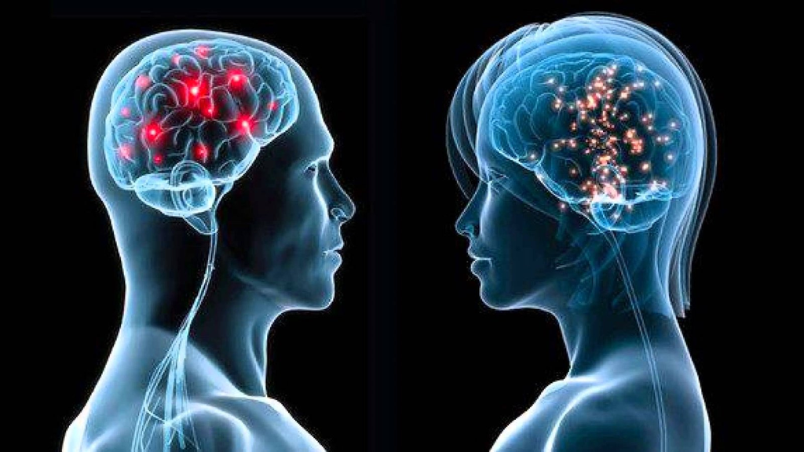

[This Photo](https://mappingignorance.org/2017/05/10/sexual-differences-in-the-human-brain/) by Unknown Author is licensed under [CC BY-NC-ND](https://creativecommons.org/licenses/by-nc-nd/3.0/)

## 2. Sexo como rol (psicología)

- Desafía la idea de que la feminidad y masculinidad se pueden medir en escalas unidimensionales (polos opuestos)
- Bem planteó que la feminidad y masculinidad eran independientes del sexo de las personas; la masculinidad y feminidad son dimensiones paralelas.
- Inicio del estudio de los estereotipos de género, diferencia entre los estereotipos descriptivos (lo que algo es) y los prescriptivos (lo que algo debe ser)

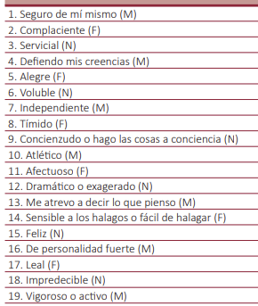

Inventario de Bem

## 3. Género como respuesta a “sexo como rol”

- Género = diferencias de tipo relacional y social entre los hombres y las mujeres.
- Crítica al uso de “roles” (Lopata & Thorne 1978) porque ignora aspectos de poder y privilegio, lo mira como funciones complementarias e implica una estabilidad a través de espacio-tiempo-grupos. No hay un solo rol universal de mujer y de hombre.

**Socialización de género:** cómo las personas que son asignadas a la categoría “hombre” al nacer, son criadas de tal manera que incentivan comportamientos “masculinos”. La socialización alimenta el mito de que el género ocurre de manera natural e inevitable.

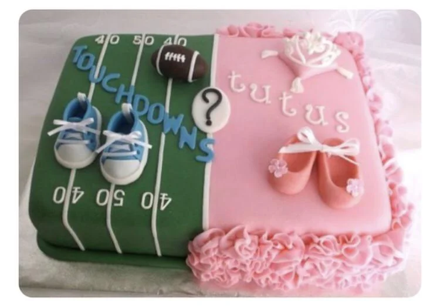

## 3. Género como respuesta: crítica antifuncionalista

(Ferree & Hess 1987; Lopata & Thorne 1978)

- Socialización por internalización y conformidad: **no explica por qué las personas no llegan a ser lo que se espera de ellas**
- “Rol” implica **complementariedad funcional** e ignora poder y privilegio
- Supone **continuidad** en el tiempo y entre situaciones: un rol abstracto, sin relaciones concretas
- Perspectiva **individualizada y esencialista**: ¿“roles raciales”?
- No existe la persona “bien socializada”: las demandas sociales son contradictorias
- **Alternativa:** género relacional (no esencial) y estructural (no individual), siempre renegociado; la estructura limita y los individuos son agentes de cambio

## 4. Hacia una comprensión social del género

**Teorías de “*doing gender*”**

- El género es algo que “hacemos”, no que “somos” (West & Zimmerman 1987). Tenemos la presión de “actuar” nuestro género como se nos espera que lo hagamos. Conectado con la teoría de Butler de la performatividad.
- Gran limitación es que hoy en día hablamos de hacer *géneros*, ya que hay mucha variación entre tipos de masculinidad, feminidad, y no binarie.

## 4. Hacia una comprensión social del género

**Teorías estructurales**

- Nacen de las primeras explicaciones estructurales a las diferencias de género en el trabajo (Kanter 1977).
  - La desigualdad no se explica por la personalidad sino por **oportunidades, poder masculino y segregación**.
  - Mismas condiciones estructurales → comportamientos similares en hombres y mujeres.
- La estructura es importante, a veces más que lo individual, **pero no es la única explicación**.
  - Tampoco podemos ignorar el género internalizado ni las expectativas de las interacciones.

## 5. Crítica al feminismo blanco/privilegiado

“la priorización del género sobre otras identidades y formas de opresión sólo reproducía jerarquías de poder racistas, heterosexistas e imperialistas” — Bokser Misses-Liwerant (2020)

Mujeres negras conceptualizaron el género como un eje de opresión, que interacciona con otros ejes de opresión mucho antes.

Crítica por asumir que la mujer blanca occidental representa a todas las mujeres.

**Interseccionalidad:** el género se entiende como *un* eje de opresión que se interrelaciona con otros (raza, sexualidad, nacionalidad, capacidad, religión, edad) (Collins 1990; Crenshaw 1989; Mohanty 2003, citadas en Risman 2021).

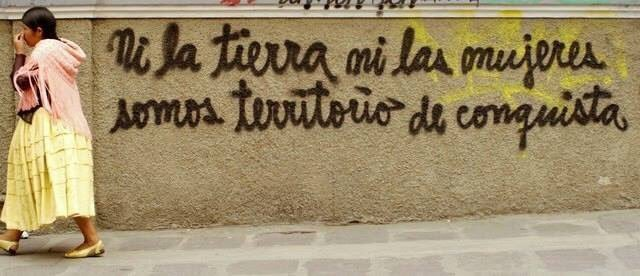

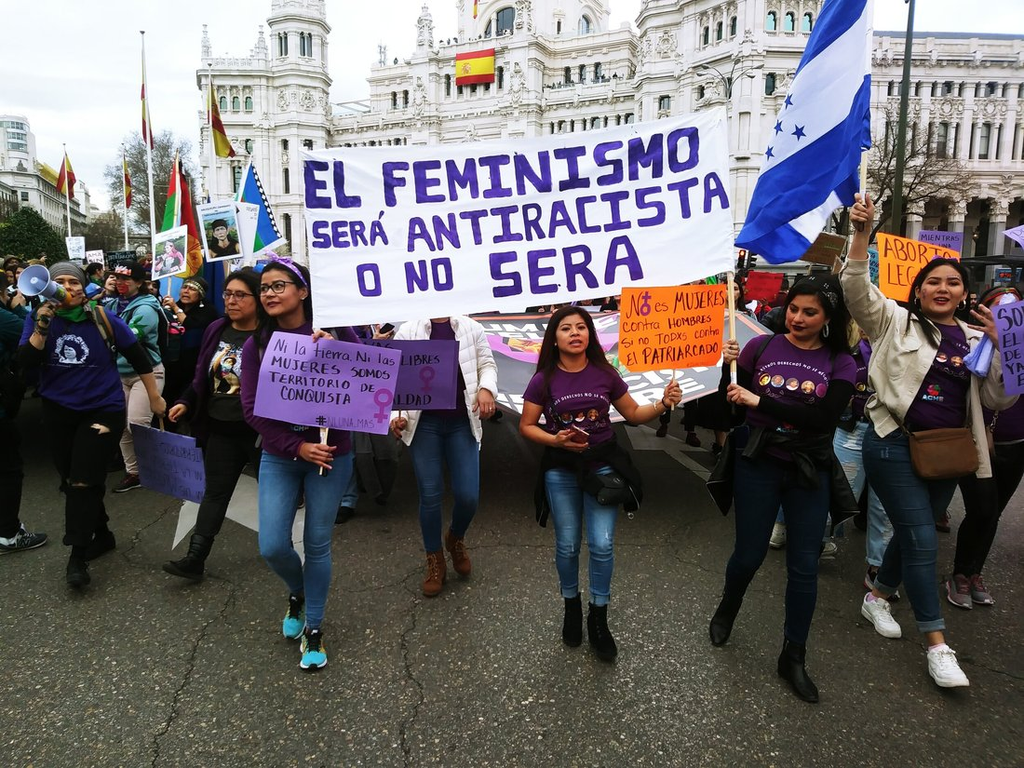

## 6. Estudios de género en América Latina

(Valdés 2001)

- Los estudios avanzan junto a un **movimiento social**: debate teórico + propuestas de acción política
- **Inicios:** “hacer visible lo invisible”, la invisibilidad social de las mujeres; trabajo productivo y reproductivo, patriarcado
- **Mercado laboral:** segregación y discriminación → lucha por la igualdad; trabajo comunitario invisible y doble o triple jornada
- **Dictaduras:** mujeres al frente de los derechos humanos desde la “lógica del afecto”; la demanda privada pasa a demanda pública por democracia
- **Democratización:** ciudadanía, derechos (violencia doméstica y sexual, derechos sexuales y reproductivos) y políticas públicas
- **Años 90:** neoliberalismo, de la redistribución a las políticas de identidad

## 6. Estudios de género en América Latina: debates y desafíos

(Valdés 2001)

- **Igualdad y diferencia:** tensión inevitable. Pensar la equidad de género como una pluralidad de principios que deben respetarse simultáneamente
- **Diferencias entre mujeres:** urbanas/rurales, clase, etnia, edad y cohorte, orientación sexual
- **Cultura y economía actúan juntas:** integrar reconocimiento y redistribución (Fraser 1997)
- **Masculinidades:** del “machismo” a la masculinidad hegemónica (Kimmel 1998). Riesgo: quedarse en identidades sin estudiar las relaciones de poder

## 7. Siglo 21

(Risman 2021)

- **Expectativas de status** enmarcan el género (Ridgeway & Correll 2004): usamos el género para clasificar lo que percibimos, categorizamos a las personas de manera inconsciente y reaccionamos a ellas según los estereotipos asociados a la categoría.
- **Lógicas culturales**
  - Las estructuras organizacionales no son neutras (Acker 1990; 1992). El género está inscrito en el diseño de las organizaciones, la definición de lo que es un trabajo y la jerarquía.
  - Cultura como una caja de herramientas de hábitos y habilidades a partir de los cuales las personas pueden construir estrategias de acción (Swidler 1986).
- **Teorías queer de género:** desafía las ideas binarias que suponen las teorías de género. Trae la sexualidad al centro: la heteronormatividad está entrelazada con la desigualdad de género (Butler 1990).
  - Estudios de personas trans que desafían la consistencia entre sexo asignado al nacer, género y sexualidad (Schilt & Westbrook 2009).

## Consenso: género en perspectiva sociológica

- El género es un sistema de estratificación que va más allá de las características individuales y que varía a lo largo de diferentes ejes de desigualdad, como la sexualidad, raza/etnia, clase social, entre otras.
- El género es un sistema social que restringe y motiva patrones de comportamiento y genera desigualdades. Es sobre la distribución de poder, propiedad y prestigio.

## Tensiones abiertas

- **Igualdad vs. diferencia:** tensión inevitable en las conceptualizaciones y políticas de género (Valdés 2001)
- **Reconocimiento vs. redistribución:** cultura y economía actúan juntas (Fraser 1997, en Valdés 2001)
- **¿Hacer o deshacer género?** Doing gender, performatividad y el “yo” (Risman 2021; Deutsch 2007)
- **Interacción, estructura y cultura:** el giro cultural es objeto de un “acalorado debate” (Risman 2021)
- **Masculinidades:** ¿identidades o relaciones de poder? (Valdés 2001)

## Actividad: ubica tu interés

En parejas (10 minutos):

- ¿Qué pregunta o tema de género les interesa investigar?
- ¿Desde qué “etapa” o perspectiva suele abordarse? ¿Cuál es la crítica que le harían las perspectivas posteriores (antifuncionalista, interseccional, latinoamericana, cultural, queer)?
- ¿Qué cambia en su pregunta si la reformulan desde otra perspectiva?

## Próxima semana: nivel micro

- **Anotación en Hypothesis:** al menos 2 anotaciones por texto obligatorio, a más tardar el martes a las 23:59.
  - Etiquetas: `pregunta`, `crítica/tensión`, `conexión`, `respuesta`.
- **Lecturas mínimas**
  - **Ridgeway, Cecilia L. and Aliya Saperstein. 2024. “Diversifying gender categories and the sex/gender system.” *Annual Review of Sociology* 50: 385–405.
  - **Martin, Karin A. 1998. “Becoming a gendered body: Practices of preschools.” *American Sociological Review* 63(4): 494–511.
  - **Human Rights Watch. 2018. Acabar con la alteración intersexual. https://www.hrw.org/es/world-report/2018/country-chapters/313454

## Referencias (clase 1)

- Acker, Joan. 1990. “Hierarchies, jobs, bodies: A theory of gendered organizations.” *Gender & Society* 4(2): 139–158.
- Acker, Joan. 1992. “From Sex Roles to Gendered Institutions.” *Contemporary Sociology* 21(5): 565–569.
- Butler, Judith. 1990. *Gender Trouble: Feminism and the Subversion of Identity*. New York: Routledge.
- Collins, Patricia Hill. 1990. *Black Feminist Thought: Knowledge, Consciousness, and the Politics of Empowerment*. Boston: Unwin Hyman.
- Crenshaw, Kimberlé. 1989. “Demarginalizing the Intersection of Race and Sex.” *University of Chicago Legal Forum* 1989: 139–167.
- Deutsch, Francine M. 2007. “Undoing Gender.” *Gender & Society* 21: 106–127.
- Ferree, Myra Marx & Beth B. Hess. 1987. “Introduction,” pp. 9–30 en *Analyzing Gender: A Handbook of Social Science Research*.
- Fraser, Nancy. 1997. *Iustitia Interrupta. Reflexiones críticas desde la posición “postsocialista”*. Bogotá: Universidad de los Andes, Siglo del Hombre Editores.
- Kanter, Rosabeth Moss. 1977. *Men and Women of the Corporation*. New York: Basic Books.
- Kimmel, Michael. 1998. “El desarrollo (de género) del subdesarrollo (de género): la producción simultánea de masculinidades hegemónicas y dependientes en Europa y Estados Unidos.” En T. Valdés y J. Olavarría (eds.), *Masculinidades y equidad de género en América Latina*. Santiago: FLACSO–UNFPA.
- Lopata, Helena Z. & Barrie Thorne. 1978. “On the term ‘sex roles’.” *Signs* 3(3): 718–721.
- Mohanty, Chandra Talpade. 2003. *Feminism without Borders: Decolonizing Theory, Practicing Solidarity*. Durham: Duke University Press.
- Ridgeway, Cecilia L. & Shelley J. Correll. 2004. “Unpacking the Gender System: A Theoretical Perspective on Gender Beliefs and Social Relations.” *Gender & Society* 18(4): 510–531.
- Risman, Barbara J. 2021. *Adónde nos llevará la generación millennial*. Universidad de Valencia (pp. 21–46).
- Schilt, Kristen & Laurel Westbrook. 2009. “Doing Gender, Doing Heteronormativity: ‘Gender Normals,’ Transgender People, and the Social Maintenance of Heterosexuality.” *Gender & Society* 23(4): 440–464.
- Stacey, Judith & Barrie Thorne. 1985. “The missing feminist revolution in sociology.” *Social Problems* 32(4): 301–316.
- Swidler, Ann. 1986. “Culture in Action: Symbols and Strategies.” *American Sociological Review* 51(2): 273–286.
- Valdés, Teresa. 2001. “Estudios de género para el siglo XXI en América Latina: algunas notas para el debate.” *Revista de la Academia* 6: 85–100.
- Valdés, Teresa & Marisa Weinstein. 1993. *Mujeres que sueñan. Las organizaciones de pobladoras en Chile: 1973–1989*. Santiago: FLACSO.
- West, Candace & Don H. Zimmerman. 1987. “Doing Gender.” *Gender & Society* 1(2): 125–151.

## Inscripción liderazgo clase